# Capstone Three_V4_18 Jun21

###### Creating an Interval of 100 for Charcters and Words Value.

```python
Char_Review_Length=Review_Length.groupby(pd.cut(Review_Length.Character_Length,np.arange(0, 1501, 100))).count()
Char_Review_Length=Char_Review_Length.rename(columns={'Character_Length':'Count'})
result_Char_Review_Length=Char_Review_Length.reset_index()
```

```python
result_Char_Review_Length.head()
```

|  | Character_Length | reviewerID | reviewerName | reviewText | Word_Length | Count |
| --- | --- | --- | --- | --- | --- | --- |
| 0 | (0, 100] | 200 | 200 | 200 | 200 | 200 |
| 1 | (100, 200] | 3075 | 3075 | 3075 | 3075 | 3075 |
| 2 | (200, 300] | 1745 | 1745 | 1745 | 1745 | 1745 |
| 3 | (300, 400] | 1061 | 1061 | 1061 | 1061 | 1061 |
| 4 | (400, 500] | 763 | 763 | 763 | 763 | 763 |

```python
Word_Review_Length=Review_Length.groupby(pd.cut(Review_Length.Word_Length,np.arange(0, 801, 100))).count()
Word_Review_Length=Word_Review_Length.rename(columns={'Word_Length':'Count'})
result_Word_Review_Length=Word_Review_Length.reset_index()
```

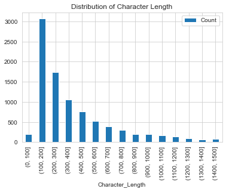

```python
result_Char_Review_Length.plot(x="Character_Length",y="Count",kind="bar",title="Distribution of Character Length")
plt.show()
```

```python
Word_Review_Length=Review_Length.groupby(pd.cut(Review_Length.Word_Length,np.arange(0, 801, 100))).count()
Word_Review_Length=Word_Review_Length.rename(columns={'Word_Length':'Count'})
result_Word_Review_Length=Word_Review_Length.reset_index()
```

```python
result_Word_Review_Length.head()
```

|  | Word_Length | reviewerID | reviewerName | reviewText | Count | Character_Length |
| --- | --- | --- | --- | --- | --- | --- |
| 0 | (0, 100] | 7023 | 7023 | 7023 | 7023 | 7023 |
| 1 | (100, 200] | 1570 | 1570 | 1570 | 1570 | 1570 |
| 2 | (200, 300] | 452 | 452 | 452 | 452 | 452 |
| 3 | (300, 400] | 199 | 199 | 199 | 199 | 199 |
| 4 | (400, 500] | 100 | 100 | 100 | 100 | 100 |

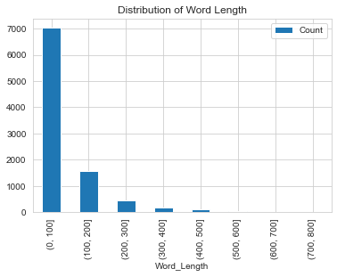

```python
result_Word_Review_Length.plot(x="Word_Length",y="Count",kind="bar",title="Distribution of Word Length")
plt.show()
```

```python
 df.info()
```

[output not shown]

[figure not shown]

```python
# Builds histogram and set the number of bins and fig size (width, height)
df.hist(bins=50, figsize=(20,15))
plt.show()
```

###### DATA PROCESSING AND FEATURE ENGINEERING

```python
def sentiments(rating):
    if (rating == 5) or (rating == 4):
        return 1
    elif rating == 3:
        return 0
    elif (rating == 2) or (rating == 1):
        return -1

# Add sentiments to the data
df["Sentiment"] = df['overall'].apply(sentiments)

df
```

|  | reviewerID | asin | reviewerName | helpful | reviewText | overall | summary | unixReviewTime | reviewTime | Month | Year | Sentiment |
| --- | --- | --- | --- | --- | --- | --- | --- | --- | --- | --- | --- | --- |
| 0 | A2IBPI20UZIR0U | 1384719342 | cassandra tu "Yeah, well, that's just like, u... | [0, 0] | Not much to write about here, but it does exac... | 5 | good | 1393545600 | 2014-02-28 | 2 | 2014 | 1 |
| 1 | A14VAT5EAX3D9S | 1384719342 | Jake | [13, 14] | The product does exactly as it should and is q... | 5 | Jake | 1363392000 | 2013-03-16 | 3 | 2013 | 1 |
| 2 | A195EZSQDW3E21 | 1384719342 | Rick Bennette "Rick Bennette" | [1, 1] | The primary job of this device is to block the... | 5 | It Does The Job Well | 1377648000 | 2013-08-28 | 8 | 2013 | 1 |
| 3 | A2C00NNG1ZQQG2 | 1384719342 | RustyBill "Sunday Rocker" | [0, 0] | Nice windscreen protects my MXL mic and preven... | 5 | GOOD WINDSCREEN FOR THE MONEY | 1392336000 | 2014-02-14 | 2 | 2014 | 1 |
| 4 | A94QU4C90B1AX | 1384719342 | SEAN MASLANKA | [0, 0] | This pop filter is great. It looks and perform... | 5 | No more pops when I record my vocals. | 1392940800 | 2014-02-21 | 2 | 2014 | 1 |
| ... | ... | ... | ... | ... | ... | ... | ... | ... | ... | ... | ... | ... |
| 10256 | A14B2YH83ZXMPP | B00JBIVXGC | Lonnie M. Adams | [0, 0] | Great, just as expected. Thank to all. | 5 | Five Stars | 1405814400 | 2014-07-20 | 7 | 2014 | 1 |
| 10257 | A1RPTVW5VEOSI | B00JBIVXGC | Michael J. Edelman | [0, 0] | I've been thinking about trying the Nanoweb st... | 5 | Long life, and for some players, a good econom... | 1404259200 | 2014-07-02 | 7 | 2014 | 1 |
| 10258 | AWCJ12KBO5VII | B00JBIVXGC | Michael L. Knapp | [0, 0] | I have tried coated strings in the past ( incl... | 4 | Good for coated. | 1405987200 | 2014-07-22 | 7 | 2014 | 1 |
| 10259 | A2Z7S8B5U4PAKJ | B00JBIVXGC | Rick Langdon "Scriptor" | [0, 0] | Well, MADE by Elixir and DEVELOPED with Taylor... | 4 | Taylor Made | 1404172800 | 2014-07-01 | 7 | 2014 | 1 |
| 10260 | A2WA8TDCTGUADI | B00JBIVXGC | TheTerrorBeyond | [0, 0] | These strings are really quite good, but I wou... | 4 | These strings are really quite good, but I wou... | 1405468800 | 2014-07-16 | 7 | 2014 | 1 |

10261 rows × 12 columns

```python
#To calculate no. of positive and negative reviews in whole dataset provided
df['Sentiment'].value_counts()
```

```
 1    9022
 0     772
-1     467
Name: Sentiment, dtype: int64
```

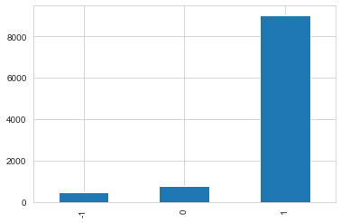

```python
df['Sentiment'].value_counts().sort_index().plot(kind='bar')
```

```python
#counting the Null Values

df.isnull().values.any()
```

```
True
```

```python
# I dropped the null values because it is a very small proportion of data

df=df.dropna()
```

```python
df.isnull().sum()
```

```
reviewerID        0
asin              0
reviewerName      0
helpful           0
reviewText        0
overall           0
summary           0
unixReviewTime    0
reviewTime        0
Month             0
Year              0
Sentiment         0
dtype: int64
```

```python
# Remove any 'neutral' ratings equal to 3
df = df[df['overall'] != 3]
```

```python
# to absolutely ensure  all data type in review Text are str

for i in range(0,len(df)-1):
    if type(df.iloc[i]['reviewText']) != str:
        df.iloc[i]['reviewText'] = str(df.iloc[i]['reviewText'])
```

```python
# counting the number of products which received feedback
#df["asin"].unique()
```

```python
#df_asin=df.pivot(columns='asin', values='overall')
#df_asin.head(n=20)
```

```python
#!pip install -q wordcloud
#nltk.download('stopwords')
#nltk.download('wordnet')
#nltk.download('punkt')
#nltk.download('averaged_perceptron_tagger')
```

### Split into Train/Test

```python
from sklearn.model_selection import train_test_split, GridSearchCV
from sklearn.feature_extraction.text import CountVectorizer, TfidfVectorizer
from sklearn.naive_bayes import BernoulliNB, MultinomialNB
from sklearn.linear_model import LogisticRegression
from sklearn.ensemble import RandomForestClassifier
import re
from sklearn import metrics
from sklearn.metrics import roc_auc_score, accuracy_score
from sklearn.pipeline import Pipeline
import re
import nltk
from nltk.corpus import stopwords
from nltk.stem.porter import PorterStemmer
from nltk.stem import SnowballStemmer, WordNetLemmatizer
from nltk import sent_tokenize, word_tokenize, pos_tag
import wordcloud
import logging
from gensim.models import word2vec
from gensim.models import Word2Vec
from gensim.models.keyedvectors import KeyedVectors
from bs4 import BeautifulSoup
```

```python
df.columns
```

```
Index(['reviewerID', 'asin', 'reviewerName', 'helpful', 'reviewText',
       'overall', 'summary', 'unixReviewTime', 'reviewTime', 'Month', 'Year',
       'Sentiment'],
      dtype='object')
```

```python
X=df[ 'reviewText']
y=df['Sentiment']
```

```python
# Split data into training set and validation
X_train, X_test, y_train, y_test = train_test_split(X, y, \
                                                    test_size=0.1, random_state=0)

print('Load %d training examples and %d validation examples. \n' %(X_train.shape[0],X_test.shape[0]))
print('Show a review in the training set : \n', X_train.iloc[10])
```

```
Load 8516 training examples and 947 validation examples.

Show a review in the training set :
 This is a very nice cable for the price. I already bent one end of it though, fortunately it still works fine. Inside the phono connector the wires are covered by white shrink plastic. Haven't noticed any hum or crackles. For sure a good buy.
```

### Part 3. Bag of Words

The goal of this project is to classify the reviews into positive and negative sentiment. There are two main steps involved. First, we need to find a word embedding to convert a text into a numerical representation. Second, we fit the numerical representations of text to machine learning algorithms or deep learning architectures. One common approach of word embedding is frequency based embedding such as Bag of Words (BoW) model. BoW model learns a vocubulary list from a given corpus and represents each document based on some counting methods of words. In this part, we will explore the model performance of using BoW with supervised learning algorithms. Here's the workflow in this part. Step 1 : Preprocess raw reviews to cleaned reviews Step 2 : Create BoW using CountVectorizer / Tfidfvectorizer in sklearn Step 3 : Transform review text to numerical representations (feature vectors) Step 4 : Fit feature vectors to supervised learning algorithm (eg. Naive Bayes, Logistic regression, etc.) Step 5 : Improve the model performance by GridSearch

### Text Preprocessing

The following text preprocessing are implemented to convert raw reviews to cleaned review, so that it will be easier for us to do feature extraction in the next step. remove html tags using BeautifulSoup remove non-character such as digits and symbols convert to lower case remove stop words such as "the" and "and" if needed convert to root words by stemming if needed

```python
#pip install beautifulsoup4
```

```python
#pip install lxml
```

```python
def cleanText(raw_text, remove_stopwords=False, stemming=False, split_text=False, \
             ):
    '''
    Convert a raw review to a cleaned review
    '''
    text = BeautifulSoup(raw_text, 'lxml').get_text()  #remove html
    letters_only = re.sub("[^a-zA-Z]", " ", text)  # remove non-character
    words = letters_only.lower().split() # convert to lower case

    if remove_stopwords: # remove stopword
        stops = set(stopwords.words("english"))
        words = [w for w in words if not w in stops]

    if stemming==True: # stemming
#         stemmer = PorterStemmer()
        stemmer = SnowballStemmer('english')
        words = [stemmer.stem(w) for w in words]

    if split_text==True:  # split text
        return (words)

    return( " ".join(words))
```

```python
 #Preprocess text data in training set and validation set
X_train_cleaned = []
X_test_cleaned = []

for x in X_train:
    X_train_cleaned.append(cleanText(x))
print('Show a cleaned review in the training set : \n',  X_train_cleaned[10])

for x in X_test:
    X_test_cleaned.append(cleanText(x))
```

```
Show a cleaned review in the training set :
 this is a very nice cable for the price i already bent one end of it though fortunately it still works fine inside the phono connector the wires are covered by white shrink plastic haven t noticed any hum or crackles for sure a good buy
```

### CountVectorizer with Mulinomial Naive Bayes (Benchmark Model)

Now we have cleaned reviews, the next step is to convert the reviews into numerical representations for machine learning algorithm. In sklearn library, we can use CountVectorizer which implements both tokenization and occurrence counting in a single class. The output is a sparse matrix representation of a document.

```python
# Fit and transform the training data to a document-term matrix using CountVectorizer
countVect = CountVectorizer()
X_train_countVect = countVect.fit_transform(X_train_cleaned)
print("Number of features : %d \n" %len(countVect.get_feature_names())) #6378
print("Show some feature names : \n", countVect.get_feature_names()[::1000])


# Train MultinomialNB classifier
mnb = MultinomialNB()
mnb.fit(X_train_countVect, y_train)
```

```
Number of features : 17396

Show some feature names :
 ['aa', 'aussie', 'butterscotch', 'conductivepolymer', 'dick', 'episode', 'fretted', 'hifidelity', 'jfet', 'marring', 'normalize', 'pin', 'realtively', 'scales', 'souned', 'tampered', 'twss', 'wifey']
```

```
MultinomialNB()
```

```python
def modelEvaluation(predictions):
    '''
    Print model evaluation to predicted result
    '''
    print ("\nAccuracy on validation set: {:.4f}".format(accuracy_score(y_test, predictions)))
    print("\nAUC score : {:.4f}".format(roc_auc_score(y_test, predictions, multi_class='ovo')))
    print("\nClassification report : \n", metrics.classification_report(y_test, predictions))
    print("\nConfusion Matrix : \n", metrics.confusion_matrix(y_test, predictions))
```

```python
# Evaluate the model on validaton set
predictions = mnb.predict(countVect.transform(X_test_cleaned))
modelEvaluation(predictions)
```

```
Accuracy on validation set: 0.9525

AUC score : 0.4994

Classification report :
               precision    recall  f1-score   support

          -1       0.00      0.00      0.00        44
           1       0.95      1.00      0.98       903

    accuracy                           0.95       947
   macro avg       0.48      0.50      0.49       947
weighted avg       0.91      0.95      0.93       947


Confusion Matrix :
 [[  0  44]
 [  1 902]]
```

```python
#pip install vaderSentiment
```

```python
#pip install -U textblob
```

### TfidfVectorizer with Logistic Regression

Some words might frequently appear but have little meaningful information about the sentiment of a particular review. Instead of using occurance counting, we can use tf-idf transform to scale down the impact of frequently appeared words in a given corpus. In sklearn library, we can use TfidfVectorizer which implements both tokenization and tf-idf weighted counting in a single class.

```python
#python download_corpora.py
```

```python
# Fit and transform the training data to a document-term matrix using TfidfVectorizer
tfidf = TfidfVectorizer(min_df=5) #minimum document frequency of 5
X_train_tfidf = tfidf.fit_transform(X_train)
print("Number of features : %d \n" %len(tfidf.get_feature_names())) #1722
print("Show some feature names : \n", tfidf.get_feature_names()[::1000])

# Logistic Regression
lr = LogisticRegression()
lr.fit(X_train_tfidf, y_train)
```

```
Number of features : 5584

Show some feature names :
 ['00', 'collector', 'frame', 'may', 'replacements', 'tightening']
```

```
LogisticRegression()
```

```python
# Look at the top 10 features with smallest and the largest coefficients
feature_names = np.array(tfidf.get_feature_names())
sorted_coef_index = lr.coef_[0].argsort()
print('\nTop 10 features with smallest coefficients :\n{}\n'.format(feature_names[sorted_coef_index[:10]]))
print('Top 10 features with largest coefficients : \n{}'.format(feature_names[sorted_coef_index[:-11:-1]]))
```

```
Top 10 features with smallest coefficients :
['not' 'something' 'returned' 'doesn' 'but' 'back' 'broke' 'work'
 'defective' 'was']

Top 10 features with largest coefficients :
['great' 'easy' 'well' 'good' 'nice' 'little' 'works' 'and' 'perfect'
 'best']
```

```python
# Evaluate on the validaton set
predictions = lr.predict(tfidf.transform(X_test_cleaned))
modelEvaluation(predictions)
```

```
Accuracy on validation set: 0.9535

AUC score : 0.5000

Classification report :
               precision    recall  f1-score   support

          -1       0.00      0.00      0.00        44
           1       0.95      1.00      0.98       903

    accuracy                           0.95       947
   macro avg       0.48      0.50      0.49       947
weighted avg       0.91      0.95      0.93       947


Confusion Matrix :
 [[  0  44]
 [  0 903]]
```

### Pipeline and GridSearch¶

# In sklearn library, we can build a pipeline to streamline the workflow and use GridSearch on the pipeline model to implement hyper-parameter tuning for both vectorizer and classifier in one go.

```python
# Building a pipeline
estimators = [("tfidf", TfidfVectorizer()), ("lr", LogisticRegression())]
model = Pipeline(estimators)


# Grid search
params = {"lr__C":[0.1, 1, 10], #regularization param of logistic regression
          "tfidf__min_df": [1, 3], #min count of words
          "tfidf__max_features": [1000, None], #max features
          "tfidf__ngram_range": [(1,1), (1,2)], #1-grams or 2-grams
          "tfidf__stop_words": [None, "english"]} #use stopwords or don't

grid = GridSearchCV(estimator=model, param_grid=params, scoring="accuracy", n_jobs=-1)
grid.fit(X_train_cleaned, y_train)
print("The best paramenter set is : \n", grid.best_params_)


# Evaluate on the validaton set
predictions = grid.predict(X_test_cleaned)
modelEvaluation(predictions)
```

```
The best paramenter set is :
 {'lr__C': 10, 'tfidf__max_features': None, 'tfidf__min_df': 3, 'tfidf__ngram_range': (1, 1), 'tfidf__stop_words': None}

Accuracy on validation set: 0.9609

AUC score : 0.6120

Classification report :
               precision    recall  f1-score   support

          -1       0.77      0.23      0.35        44
           1       0.96      1.00      0.98       903

    accuracy                           0.96       947
   macro avg       0.87      0.61      0.67       947
weighted avg       0.95      0.96      0.95       947


Confusion Matrix :
 [[ 10  34]
 [  3 900]]
```

### Part 4. Word2Vec

Another common approach of word embedding is prediction based embedding, such as Word2Vec model. In gist, Word2Vec is a combination of two techniques: Continuous Bag of Words (CBoW) and skip-gram model. Both are shallow neural networks which learn weights for word vector representations. In this part, we will train Word2Vec model to create our own word vector representations using gensim library. Then we fit the feature vectors of the reviews to Random Forest Classifier. Here's the workflow of this part. Step 1 : Parse review text to sentences (Word2Vec model takes a list of sentences as inputs) Step 2 : Create volcabulary list using Word2Vec model Step 3 : Transform each review into numerical representation by computing average feature vectors of words therein Step 4 : Fit the average feature vectors to Random Forest Classifier

### Parsing Review into Sentences

Word2Vec model takes a list of sentences as inputs and outputs word vector representations for words in the vocalbulary list created. Before we train the Word2Vec model, we have to parse reviews in the training set into sentences.

```python
# Split review text into parsed sentences uisng NLTK's punkt tokenizer
# nltk.download()
tokenizer = nltk.data.load('tokenizers/punkt/english.pickle')

def parseSent(review, tokenizer, remove_stopwords=False):
    '''
    Parse text into sentences
    '''
    raw_sentences = tokenizer.tokenize(review.strip())
    sentences = []
    for raw_sentence in raw_sentences:
        if len(raw_sentence) > 0:
            sentences.append(cleanText(raw_sentence, remove_stopwords, split_text=True))
    return sentences


# Parse each review in the training set into sentences
sentences = []
for review in X_train_cleaned:
    sentences += parseSent(review, tokenizer)

print('%d parsed sentence in the training set\n'  %len(sentences))
print('Show a parsed sentence in the training set : \n',  sentences[10])
```

```
8510 parsed sentence in the training set

Show a parsed sentence in the training set :
 ['this', 'is', 'a', 'very', 'nice', 'cable', 'for', 'the', 'price', 'i', 'already', 'bent', 'one', 'end', 'of', 'it', 'though', 'fortunately', 'it', 'still', 'works', 'fine', 'inside', 'the', 'phono', 'connector', 'the', 'wires', 'are', 'covered', 'by', 'white', 'shrink', 'plastic', 'haven', 't', '…
```

### Creating Volcabulary List usinhg Word2Vec Model

Now we have a set of cleaned and parsed sentences from the training data, we can train our own word evctor representations by sepcifiying the embedding dimension (= length of feature vector).

```python
# Fit parsed sentences to Word2Vec model
# logging.basicConfig(format='%(asctime)s : %(levelname)s : %(message)s',level=logging.INFO)

num_features = 300  #embedding dimension
min_word_count = 10
num_workers = 4
context = 10
downsampling = 1e-3

print("Training Word2Vec model ...\n")
w2v = Word2Vec(sentences, workers=num_workers, vector_size=num_features, min_count = min_word_count,\
                 window = context, sample = downsampling)
w2v.init_sims(replace=True)
w2v.save("w2v_300features_10minwordcounts_10context") #save trained word2vec model

print("Number of words in the vocabulary list : %d \n" %len(w2v.wv.index_to_key)) #4016
print("Show first 10 words in the vocalbulary list  vocabulary list: \n", w2v.wv.index_to_key[0:10])
```

```
Training Word2Vec model ...

Number of words in the vocabulary list : 3862

Show first 10 words in the vocalbulary list  vocabulary list:
 ['the', 'i', 'a', 'and', 'it', 'to', 'is', 'of', 'for', 'this']
```

### Averaging Feature Vectors

Now we have created a volcabulary list of words, with each word having a word representation (ie. feature vector of dim 300). To find a numerical representation for a review, we run through each word in a review text. For words appear in the volcabulary list, we compute the average feature vectors of all those words. The average feature vector is the numerical represenation of the review.

```python
# Transfrom the training data into feature vectors

def makeFeatureVec(review, model, num_features):
    '''
    Transform a review to a feature vector by averaging feature vectors of words
    appeared in that review and in the volcabulary list created
    '''
    featureVec = np.zeros((num_features,),dtype="float32")
    nwords = 0.
    index_to_key_set = set(model.wv.index_to_key) #index2word is the volcabulary list of the Word2Vec model
    isZeroVec = True
    for word in review:
        if word in index_to_key_set:
            nwords = nwords + 1.
            featureVec = np.add(featureVec, model.wv[word])
            isZeroVec = False
    if isZeroVec == False:
        featureVec = np.divide(featureVec, nwords)
    return featureVec


def getAvgFeatureVecs(reviews, model, num_features):
    '''
    Transform all reviews to feature vectors using makeFeatureVec()
    '''
    counter = 0
    reviewFeatureVecs = np.zeros((len(reviews),num_features),dtype="float32")
    for review in reviews:
        reviewFeatureVecs[counter] = makeFeatureVec(review, model,num_features)
        counter = counter + 1
    return reviewFeatureVecs
```

```python
# Get feature vectors for training set
X_train_cleaned = []
for review in X_train:
    X_train_cleaned.append(cleanText(review, remove_stopwords=True, split_text=True))
trainVector = getAvgFeatureVecs(X_train_cleaned, w2v, num_features)
print("Training set : %d feature vectors with %d dimensions" %trainVector.shape)


# Get feature vectors for validation set
X_test_cleaned = []
for review in X_test:
    X_test_cleaned.append(cleanText(review, remove_stopwords=True, split_text=True))
testVector = getAvgFeatureVecs(X_test_cleaned, w2v, num_features)
print("Validation set : %d feature vectors with %d dimensions" %testVector.shape)


# debugging
# print("Checkinf for NaN and Inf")
# print("np.inf=", np.where(np.isnan(trainVector)))
# print("is.inf=", np.where(np.isinf(trainVector)))
# print("np.max=", np.max(abs(trainVector)))
```

```
Training set : 8516 feature vectors with 300 dimensions
Validation set : 947 feature vectors with 300 dimensions
```

```python
print(testVector)
```

```
[[-0.00074237  0.0253377   0.03233078 ... -0.01503688  0.02058244
  -0.04381348]
 [ 0.02597584  0.00408622  0.00343771 ...  0.00229448 -0.00797011
  -0.0193021 ]
 [ 0.00127376  0.05432184  0.03911382 ... -0.01215345  0.01809244
  -0.05058024]
 ...
 [ 0.01062282  0.02557532  0.03633013 ...  0.01718455  0.01416876
  -0.02625711]
 [ 0.00534291  0.06950457  0.02814169 ... -0.02836627  0.02362776
  -0.01927024]
 [ 0.01240816  0.01752891 -0.03402667 ... -0.03701589  0.01586573
   0.01353212]]
```

```python
print(y_train)
```

```
3102     1
5081     1
8789     1
5883     1
8438     1
        ..
8541     1
10005    1
5242     1
3503     1
2936     1
Name: Sentiment, Length: 8516, dtype: int64
```

### Random Forest Classifer

We can now train Random Forest Classifier using feature vectors of reviews in the training set.

```python
from imblearn.pipeline import make_pipeline
```

```python
from imblearn.over_sampling import SMOTE
```

```python
oversample = SMOTE(sampling_strategy=0.1)
trainVectorO, y_trainO = oversample.fit_resample(trainVector, y_train)
```

```python
under = RandomUnderSampler(sampling_strategy=0.9)
```

```python
trainVectorU, y_trainU = under.fit_resample(trainVector, y_train)
```

```python
# Random Forest Classifier
rf = RandomForestClassifier(n_estimators=100)
rf.fit(trainVectorU, y_trainU)
predictions = rf.predict(testVector)
modelEvaluation(predictions)
```

```
Accuracy on validation set: 0.7012

AUC score : 0.6595

Classification report :
               precision    recall  f1-score   support

          -1       0.09      0.61      0.16        44
           1       0.97      0.71      0.82       903

    accuracy                           0.70       947
   macro avg       0.53      0.66      0.49       947
weighted avg       0.93      0.70      0.79       947


Confusion Matrix :
 [[ 27  17]
 [266 637]]
```

```python
from imblearn.ensemble import BalancedRandomForestClassifier
brf = BalancedRandomForestClassifier(n_estimators=100, random_state=0)
```

```python
brf.fit(trainVector, y_train)
predictions = brf.predict(testVector)
modelEvaluation(predictions)
```

```
Accuracy on validation set: 0.7086

AUC score : 0.6634

Classification report :
               precision    recall  f1-score   support

          -1       0.09      0.61      0.16        44
           1       0.97      0.71      0.82       903

    accuracy                           0.71       947
   macro avg       0.53      0.66      0.49       947
weighted avg       0.93      0.71      0.79       947


Confusion Matrix :
 [[ 27  17]
 [259 644]]
```

```python
#!pip3 install xgboost
```

```python
import xgboost; print(xgboost.__version__)
```

```
0.90
```

### XGBoost Model for Classification

```python
from numpy import mean
from sklearn.datasets import make_classification
from sklearn.model_selection import cross_val_score
from sklearn.model_selection import RepeatedStratifiedKFold
from xgboost import XGBClassifier
```

```python
# define model
xg = XGBClassifier()
xg.fit(trainVector, y_train)
predictionsxg = xg.predict(testVector)
modelEvaluation(predictionsxg)
```

```
Accuracy on validation set: 0.9535

AUC score : 0.5000

Classification report :
               precision    recall  f1-score   support

          -1       0.00      0.00      0.00        44
           1       0.95      1.00      0.98       903

    accuracy                           0.95       947
   macro avg       0.48      0.50      0.49       947
weighted avg       0.91      0.95      0.93       947


Confusion Matrix :
 [[  0  44]
 [  0 903]]
```

```python
# define model
xg = XGBClassifier()
xg.fit(trainVectorU, y_trainU)
predictionsxgii = xg.predict(testVector)
modelEvaluation(predictionsxgii)
```

```
Accuracy on validation set: 0.7223

AUC score : 0.6814

Classification report :
               precision    recall  f1-score   support

          -1       0.10      0.64      0.18        44
           1       0.98      0.73      0.83       903

    accuracy                           0.72       947
   macro avg       0.54      0.68      0.50       947
weighted avg       0.94      0.72      0.80       947


Confusion Matrix :
 [[ 28  16]
 [247 656]]
```

```python
from numpy import mean
from sklearn.model_selection import cross_val_score
from sklearn.model_selection import RepeatedStratifiedKFold
```

```python
# define evaluation procedure
cv = RepeatedStratifiedKFold(n_splits=10, n_repeats=3, random_state=1)
# evaluate model
scores = cross_val_score(model, trainVector, y_train, scoring='roc_auc', cv=cv, n_jobs=-1)
# summarize performance
print('Mean ROC AUC: %.5f' % mean(scores))
```

```
Mean ROC AUC: nan
```

I am going to try XG Boost becuase it can handel the imbalace dataset better. But it is not helping here.

```python
#conda install -c conda-forge imbalanced-learn
```

```python
#import imblearn
#print(imblearn.__version__)
```

```python
#import site
#site.getsitepackages()

# /your/path/from/python
```

```python
#pip show imblearn
```

```python
#pip config set global.target C:\\Users\\zsoltani\\Anaconda3\\envs\\ZSPython\\lib\\site-packages
```

```python
#pip install imblearn
```

### Part 6. Word Cloud

```python
def create_word_cloud(sentiment):
    try:
        word_cloud_collection = ''

        if sentiment == 1:
            df_reviews = df[df["Sentiment"]==1]["reviewText"]

        if sentiment == -1:
            df_reviews = df[df["Sentiment"]==-1]["reviewText"]

        for val in df_reviews.str.lower():
            tokens = nltk.word_tokenize(val)
            tokens = [word for word in tokens if word not in stopwords.words('english')]
            for words in tokens:
                word_cloud_collection = word_cloud_collection + words + ' '

        wordcloud = WordCloud(max_font_size=50, width=500, height=300).generate(word_cloud_collection)
        plt.figure(figsize=(20,20))
        plt.imshow(wordcloud)
        plt.axis("off")
        plt.show()

    except:
        pass
```

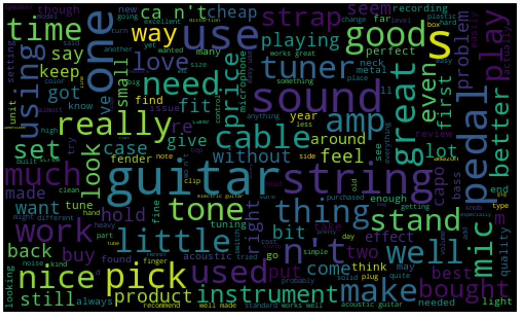

```python
create_word_cloud(sentiment=1)
```

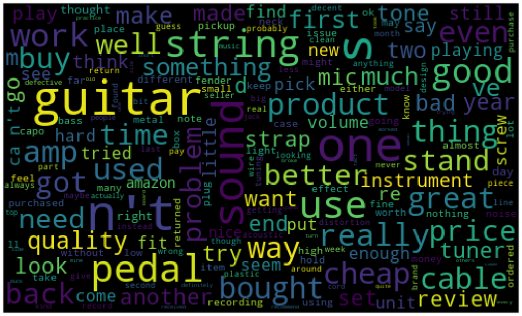

```python
create_word_cloud(sentiment=-1)
```